# ФББ - R - Домашнее задание №6

Данил Сидиков

19 10 2023

# Подгрузка пакетов

```r
library('tidyverse') #загрузим установленный пакет tidyverse в текущую R сессию
library(ggrepel)
```

# Задание №1

## Задание 1.1

> Из набора данных msleep отберите столбцы, согласно следующим заданиям.

> Отберите колонку name и колонки, названия которых начинаются на “sleep” или оканчиваются на “wt”

> Отберите колонки с названиями из вектора c(“name”, “genus”, “vore”, “order”, “conservation”)

> Отберите все колонки, содержащие числовые значения Пересортируйте колонки так, чтобы в начале шли столбцы conservation и sleep_total

```r
#Отберем колонку name и колонки, названия которых начинаются на “sleep” или оканчиваются на “wt”
msleep %>%
  select(name | starts_with("sleep") | ends_with("wt")) %>% head(3)
```

```
## # A tibble: 3 x 6
##   name            sleep_total sleep_rem sleep_cycle brainwt bodywt
##   <chr>                 <dbl>     <dbl>       <dbl>   <dbl>  <dbl>
## 1 Cheetah                12.1      NA            NA NA       50
## 2 Owl monkey             17         1.8          NA  0.0155   0.48
## 3 Mountain beaver        14.4       2.4          NA NA        1.35
```

```r
#Отберем колонки с названиями из вектора c("name", "genus", "vore", "order", "conservation")
msleep %>%
  select(c("name", "genus", "vore", "order", "conservation")) %>% head(3)
```

```
## # A tibble: 3 x 5
##   name            genus      vore  order     conservation
##   <chr>           <chr>      <chr> <chr>     <chr>
## 1 Cheetah         Acinonyx   carni Carnivora lc
## 2 Owl monkey      Aotus      omni  Primates  <NA>
## 3 Mountain beaver Aplodontia herbi Rodentia  nt
```

```r
#Отберем все колонки, содержащие числовые значения
msleep %>%
  select(where(is.numeric)) %>% head(5)
```

```
## # A tibble: 5 x 6
##   sleep_total sleep_rem sleep_cycle awake  brainwt  bodywt
##         <dbl>     <dbl>       <dbl> <dbl>    <dbl>   <dbl>
## 1        12.1      NA        NA      11.9 NA        50
## 2        17         1.8      NA       7    0.0155    0.48
## 3        14.4       2.4      NA       9.6 NA         1.35
## 4        14.9       2.3       0.133   9.1  0.00029   0.019
## 5         4         0.7       0.667  20    0.423   600
```

```r
#Пересортируем колонки так, чтобы в начале шли столбцы conservation и sleep_total
msleep %>%
  select(conservation, sleep_total, everything()) %>% head(3)
```

```
## # A tibble: 3 x 11
##   conservation sleep_total name    genus vore  order sleep_rem sleep_cycle awake
##   <chr>              <dbl> <chr>   <chr> <chr> <chr>     <dbl>       <dbl> <dbl>
## 1 lc                  12.1 Cheetah Acin~ carni Carn~      NA            NA  11.9
## 2 <NA>                17   Owl mo~ Aotus omni  Prim~       1.8          NA   7
## 3 nt                  14.4 Mounta~ Aplo~ herbi Rode~       2.4          NA   9.6
## # i 2 more variables: brainwt <dbl>, bodywt <dbl>
```

## Задание 1.2

> Ранее чтобы трансформировать за раз несколько столбцов использовались функции mutate_all, mutate_at и mutate_if. Сейчас их все заменяет комбинация простого mutate и функции across. Стоит иметь ввиду, что в таком случае столбцы модифицируются, а не создаются новые (но можно создавать и новые).

> Транформируйте все-все столбцы с помощью tolower - функции, которая переводит весь текст (так ли это?) в строчные буквы.

> Трансформируйте тем же образом только текстовые столбцы (characters).

> Трансформируйте столбцы, названия которых содержат слово “sleep”: переведите часы в минуты.

> Создайте новые столбцы, в которых все значения, выраженные в часах будут переведены в минуты.

> Логарифмируйте все числовые значения - трансформируйте уже существующие столбцы.

> Одновременно с переводом часов в минуты, логарифмируйте все числовые значения и создайте для транформированных значений новые колонки.

```r
#Посмотрим датасет msleep
head(msleep, n = 5)
```

```
## # A tibble: 5 x 11
##   name    genus vore  order conservation sleep_total sleep_rem sleep_cycle awake
##   <chr>   <chr> <chr> <chr> <chr>              <dbl>     <dbl>       <dbl> <dbl>
## 1 Cheetah Acin~ carni Carn~ lc                  12.1      NA        NA      11.9
## 2 Owl mo~ Aotus omni  Prim~ <NA>                17         1.8      NA       7
## 3 Mounta~ Aplo~ herbi Rode~ nt                  14.4       2.4      NA       9.6
## 4 Greate~ Blar~ omni  Sori~ lc                  14.9       2.3       0.133   9.1
## 5 Cow     Bos   herbi Arti~ domesticated         4         0.7       0.667  20
## # i 2 more variables: brainwt <dbl>, bodywt <dbl>
```

```r
#Транформируем все-все столбцы с помощью tolower - функции, которая переводит весь текст в строчные буквы.
msleep %>%
  mutate(across(everything(), tolower))  %>% head(3)
```

```
## # A tibble: 3 x 11
##   name    genus vore  order conservation sleep_total sleep_rem sleep_cycle awake
##   <chr>   <chr> <chr> <chr> <chr>        <chr>       <chr>     <chr>       <chr>
## 1 cheetah acin~ carni carn~ lc           12.1        <NA>      <NA>        11.9
## 2 owl mo~ aotus omni  prim~ <NA>         17          1.8       <NA>        7
## 3 mounta~ aplo~ herbi rode~ nt           14.4        2.4       <NA>        9.6
## # i 2 more variables: brainwt <chr>, bodywt <chr>
```

```r
#Весь текст поменял символы на строчные, также все столбцы теперь имеют тип chr

#Трансформируем тем же образом только текстовые столбцы (characters).
msleep %>%
  mutate(across(where(is.character), tolower))  %>% head(3)
```

```
## # A tibble: 3 x 11
##   name    genus vore  order conservation sleep_total sleep_rem sleep_cycle awake
##   <chr>   <chr> <chr> <chr> <chr>              <dbl>     <dbl>       <dbl> <dbl>
## 1 cheetah acin~ carni carn~ lc                  12.1      NA            NA  11.9
## 2 owl mo~ aotus omni  prim~ <NA>                17         1.8          NA   7
## 3 mounta~ aplo~ herbi rode~ nt                  14.4       2.4          NA   9.6
## # i 2 more variables: brainwt <dbl>, bodywt <dbl>
```

```r
#Трансформируем столбцы, названия которых содержат слово “sleep”: переведите часы в минуты.
msleep %>%
  mutate(across(contains("sleep"), \(x) x*60))  %>% head(5)
```

```
## # A tibble: 5 x 11
##   name    genus vore  order conservation sleep_total sleep_rem sleep_cycle awake
##   <chr>   <chr> <chr> <chr> <chr>              <dbl>     <dbl>       <dbl> <dbl>
## 1 Cheetah Acin~ carni Carn~ lc                   726        NA       NA     11.9
## 2 Owl mo~ Aotus omni  Prim~ <NA>                1020       108       NA      7
## 3 Mounta~ Aplo~ herbi Rode~ nt                   864       144       NA      9.6
## 4 Greate~ Blar~ omni  Sori~ lc                   894       138        8.00   9.1
## 5 Cow     Bos   herbi Arti~ domesticated         240        42       40.0   20
## # i 2 more variables: brainwt <dbl>, bodywt <dbl>
```

```r
#Создадим новые столбцы, в которых все значения, выраженные в часах будут переведены в минуты.
msleep1 <- msleep %>%
  mutate(across(contains("sleep")|awake, list(min = ~.x*60)))
colnames(msleep1)
```

```
##  [1] "name"            "genus"           "vore"            "order"
##  [5] "conservation"    "sleep_total"     "sleep_rem"       "sleep_cycle"
##  [9] "awake"           "brainwt"         "bodywt"          "sleep_total_min"
## [13] "sleep_rem_min"   "sleep_cycle_min" "awake_min"
```

```r
head(msleep1, n=3) #отобразим начальные столбцы
```

```
## # A tibble: 3 x 15
##   name    genus vore  order conservation sleep_total sleep_rem sleep_cycle awake
##   <chr>   <chr> <chr> <chr> <chr>              <dbl>     <dbl>       <dbl> <dbl>
## 1 Cheetah Acin~ carni Carn~ lc                  12.1      NA            NA  11.9
## 2 Owl mo~ Aotus omni  Prim~ <NA>                17         1.8          NA   7
## 3 Mounta~ Aplo~ herbi Rode~ nt                  14.4       2.4          NA   9.6
## # i 6 more variables: brainwt <dbl>, bodywt <dbl>, sleep_total_min <dbl>,
## #   sleep_rem_min <dbl>, sleep_cycle_min <dbl>, awake_min <dbl>
```

```r
head(msleep1[10:15], n=3) #отобразим добавленные столбцы
```

```
## # A tibble: 3 x 6
##   brainwt bodywt sleep_total_min sleep_rem_min sleep_cycle_min awake_min
##     <dbl>  <dbl>           <dbl>         <dbl>           <dbl>     <dbl>
## 1 NA       50                726            NA              NA       714
## 2  0.0155   0.48            1020           108              NA       420
## 3 NA        1.35             864           144              NA       576
```

```r
#Логарифмируем все числовые значения - трансформируем уже существующие столбцы.
msleep1 <- msleep1 %>%
  mutate(across(where(is.numeric), \(x) log10(x)))
head(msleep1[10:15], n=3) #отобразим добавленные столбцы
```

```
## # A tibble: 3 x 6
##   brainwt bodywt sleep_total_min sleep_rem_min sleep_cycle_min awake_min
##     <dbl>  <dbl>           <dbl>         <dbl>           <dbl>     <dbl>
## 1   NA     1.70             2.86         NA                 NA      2.85
## 2   -1.81 -0.319            3.01          2.03              NA      2.62
## 3   NA     0.130            2.94          2.16              NA      2.76
```

```r
#Одновременно с переводом часов в минуты, логарифмируем все числовые значения и создадим для транформированных значений новые колонки.
msleep1 <- msleep %>%
  mutate(across(contains("sleep")|awake, \(x) x*60)) %>% #Переведем часы в минуты
  mutate(across(where(is.numeric), list(logs = ~log(.x)))) #Создадим новые столбцы для всех трансформированных значений
head(msleep1[12:17]) #отобразим добавленные столбцы
```

```
## # A tibble: 6 x 6
##   sleep_total_logs sleep_rem_logs sleep_cycle_logs awake_logs brainwt_logs
##              <dbl>          <dbl>            <dbl>      <dbl>        <dbl>
## 1             6.59          NA               NA          6.57       NA
## 2             6.93           4.68            NA          6.04       -4.17
## 3             6.76           4.97            NA          6.36       NA
## 4             6.80           4.93             2.08       6.30       -8.15
## 5             5.48           3.74             3.69       7.09       -0.860
## 6             6.76           4.88             3.83       6.36       NA
## # i 1 more variable: bodywt_logs <dbl>
```

## Задание 1.3

> Отберите строки из набора данных msleep по следующим запросам.

> Оставьте только те строки, в которых все строковые значения не равны NA.

> Оставьте только те строки, где name, genus или order начинаются на P.

> Найдите тех животных, у которых значения sleep_total и awake примерно равны - отличаются максимум на 1 час.

```r
#Оставим только те строки, в которых все строковые значения не равны NA.
msleep1 <- msleep %>%
  filter(if_all(everything(), ~!is.na(.)))
head(msleep1, n = 5)
```

```
## # A tibble: 5 x 11
##   name    genus vore  order conservation sleep_total sleep_rem sleep_cycle awake
##   <chr>   <chr> <chr> <chr> <chr>              <dbl>     <dbl>       <dbl> <dbl>
## 1 Greate~ Blar~ omni  Sori~ lc                  14.9       2.3       0.133   9.1
## 2 Cow     Bos   herbi Arti~ domesticated         4         0.7       0.667  20
## 3 Dog     Canis carni Carn~ domesticated        10.1       2.9       0.333  13.9
## 4 Guinea~ Cavis herbi Rode~ domesticated         9.4       0.8       0.217  14.6
## 5 Chinch~ Chin~ herbi Rode~ domesticated        12.5       1.5       0.117  11.5
## # i 2 more variables: brainwt <dbl>, bodywt <dbl>
```

```r
#Оставим только те строки, где name, genus или order начинаются на P.
msleep1 <- msleep %>%
  filter(startsWith(name, "P") | startsWith(genus, "P") | startsWith(order, "P"))
head(msleep1, n = 5)
```

```
## # A tibble: 5 x 11
##   name    genus vore  order conservation sleep_total sleep_rem sleep_cycle awake
##   <chr>   <chr> <chr> <chr> <chr>              <dbl>     <dbl>       <dbl> <dbl>
## 1 Owl mo~ Aotus omni  Prim~ <NA>                17         1.8      NA       7
## 2 Three-~ Brad~ herbi Pilo~ <NA>                14.4       2.2       0.767   9.6
## 3 Grivet  Cerc~ omni  Prim~ lc                  10         0.7      NA      14
## 4 Asian ~ Elep~ herbi Prob~ en                   3.9      NA        NA      20.1
## 5 Horse   Equus herbi Peri~ domesticated         2.9       0.6       1      21.1
## # i 2 more variables: brainwt <dbl>, bodywt <dbl>
```

```r
#Найдем тех животных, у которых значения sleep_total и awake примерно равны - отличаются максимум на 1 час.
msleep1 <- msleep %>%
  filter(abs(sleep_total - awake) <= 1)
head(msleep1, n = 5)
```

```
## # A tibble: 5 x 11
##   name    genus vore  order conservation sleep_total sleep_rem sleep_cycle awake
##   <chr>   <chr> <chr> <chr> <chr>              <dbl>     <dbl>       <dbl> <dbl>
## 1 Cheetah Acin~ carni Carn~ lc                  12.1      NA        NA      11.9
## 2 Chinch~ Chin~ herbi Rode~ domesticated        12.5       1.5       0.117  11.5
## 3 Domest~ Felis carni Carn~ domesticated        12.5       3.2       0.417  11.5
## 4 House ~ Mus   herbi Rode~ nt                  12.5       1.4       0.183  11.5
## 5 Deer m~ Pero~ <NA>  Rode~ <NA>                11.5      NA        NA      12.5
## # i 2 more variables: brainwt <dbl>, bodywt <dbl>
```

## Задание 1.4

> Сгруппируйте датафрейм по переменной vore и посчитайте средние и максимальные значения по всем числовым признакам.

```r
#Сгруппируем датафрейм по переменной vore и посчитаем средние и максимальные значения по всем числовым признакам.

result <- msleep %>%
  group_by(vore) %>%
  summarise(across(where(is.numeric), list(mean = mean, max = max), na.rm = TRUE))
result
```

```
## # A tibble: 5 x 13
##   vore    sleep_total_mean sleep_total_max sleep_rem_mean sleep_rem_max
##   <chr>              <dbl>           <dbl>          <dbl>         <dbl>
## 1 carni              10.4             19.4           2.29           6.6
## 2 herbi               9.51            16.6           1.37           3.4
## 3 insecti            14.9             19.9           3.52           6.1
## 4 omni               10.9             18             1.96           4.9
## 5 <NA>               10.2             13.7           1.88           2.7
## # i 8 more variables: sleep_cycle_mean <dbl>, sleep_cycle_max <dbl>,
## #   awake_mean <dbl>, awake_max <dbl>, brainwt_mean <dbl>, brainwt_max <dbl>,
## #   bodywt_mean <dbl>, bodywt_max <dbl>
```

```r
#Аналогично и с другими столбцами
colnames(result)
```

```
##  [1] "vore"             "sleep_total_mean" "sleep_total_max"  "sleep_rem_mean"
##  [5] "sleep_rem_max"    "sleep_cycle_mean" "sleep_cycle_max"  "awake_mean"
##  [9] "awake_max"        "brainwt_mean"     "brainwt_max"      "bodywt_mean"
## [13] "bodywt_max"
```

# Задание №2

> Воспользуйтесь набором данных starwars - он доступен из пакета tidyverse. Этот набор данных содержит информацию о персонажах вселенной Звездных Войн (взглянить в справку о датасете, чтобы узнать детали).

> Посчитайте в скольки фильмах появлялся каждый из персонажей, а также определите был ли он героем эпизода “Новая надежда” (A New Hope). Поскольку столбец films (а также столбцы vehicles и starships) являются не просто столбцами, а столбцами-списками (list columns), то есть представляют из себя не обычные простые вектора, а списки. Столбец films можно представить как список, в котором каждый элемент - это значение в каждой следующей строке датафрейма, и элемент этого списка является строковым вектором. Из-за такой сложной структуры столбца для работы с ним имеет смысл использовать функции семейства map (они отлично справляются со списками). Map можно (и нужно) использовать при создании новых столбцов (с информацией о количестве фильмов и т.д.) с помощью mutate.

> После того, как вы справились с подсчетами, оставьте только персонажей, которые были в эпизоде “Новая надежда” и постройте график дотплот с помощью geom_point(), который бы показывал, какие персонажи разных рас (species) в скольких фильмах появлялись. По оси X - число фильмов, по Y - раса (species), каждая точка - один персонаж. Цветом точки продублируйте информацию о расе, размером точки - число фильмов. Подпишите каждую точку - добавьте на график имена персонажей.

> Сделайте график понятным (подпишите названия осей, добавьте название и т.д.) и визуально приятным.

[figure not shown]

```r
#Добавим логический столбец - принимал ли он участие в фильме A New Hope
sw <- starwars %>%
  mutate(is_hero_anh = map_lgl(films, ~ "A New Hope" %in% (.x)))
#Добавим столбец, где указано количество фильмов, где он снимался
sw <- sw %>%
  mutate(num_films = map_int(films, length))
#Отберем героев, которые снимались в фильме A New Hope
sw_filtered <- sw %>%
  filter(is_hero_anh == TRUE)
#Установим уровни категориальных данных
spec <- fct_rev(factor(sw_filtered$species, levels = c("Droid","Wookiee","Hutt","Human","Rodian")))

ggplot(sw_filtered, aes(x = num_films, y = spec , color = spec, size = num_films)) +
  geom_point() +
  geom_label_repel(aes(label = name), size = 3, min.segment.length = unit(0, 'lines')) + #Создадим рамки для подписей и расположим их так, чтобы они не мешали друг другу
  labs(x = "Number of films", y = "Species", title = "The characters of STARWARS: A NEW HOPE") + #Обозначим оси
  scale_x_continuous(breaks = c(1:7)) + #Установим порядок значений на оси
  theme_minimal() +
  theme(plot.title = element_text(hjust = 0.5, face = "bold"), legend.position = "none", axis.text = element_text(size = 10, face = "bold")) + #Установим стиль
  scale_color_manual(values = c("Human" = "blue", "Droid" = "red", "Rodian" = "green", "Wookiee" = "purple", "Hutt" = "orange")) #Зафиксируем цвета за категориями
```

# Задание №3

> Скачайте данные про лемуров (lemurs.zip) - https://github.com/kirushka/datasets/raw/main/splitted%20datasets/lemurs.zip. Скачайте и разархивируйте файл в свою рабочую директорию (для этого использовать R не нужно, делайте это как вам привычнее). В папке weights лежат таблицы с 3-мя измерениями веса разных лемуров. Данные по каждому лемуру содержатся в своем файле. Прочитайте эти данные и объедините их в один датафрейм. Не потеряйте информацию об имени лемура (содержится в названии файла).

> Объедините данные о весе лемуров с более обширными данными с их биографическими данными - они содержатся в файле lemur_info.csv.

> С помощью линейной диаграммы изобразите изменение массы тела лемуров (отберите только тех лемуров, для которых есть данные по всем трем временным точкам измерения массы тела). Цветом линий отобразите пол животных.

> Сделайте график понятным (подпишите названия осей, добавьте название и т.д.) и визуально приятным.

```r
#Я скачал архив, распаковал его И положил в рабочую директорию два объекта. Одну папку weights и файл lemur_info.csv

input_files <- dir("./weights/") #Занесем в вектор input_files имена всех .tsv в папке weights, которая находится в текущей директории

input_files <- paste("./weights/", input_files, sep="") #Добавим путь к файлам из текущей директории
head(input_files, n = 5)
```

```
## [1] "./weights/Agatha.tsv"      "./weights/Angelique.tsv"
## [3] "./weights/Annabel Lee.tsv" "./weights/Ardrey-A.tsv"
## [5] "./weights/Ardrey.tsv"
```

```r
#Напишем функцию для чтения файла и добавления имени файла в dataframe
read_file <- function(file) {
  df <- read_tsv(file, show_col_types = FALSE) #Прочитаем файлы, уберем предупреждения
  df$name <- str_remove(basename(file),".tsv") #Оставим только название файла
  return(df)
}

#Объединяем результаты в один dataframe
result <- map_dfr(input_files, read_file)
#Преобразуем таблицу в широкий формат
result <- pivot_wider(result,names_from = weight_date, values_from = weight)
head(result, n = 5)
```

```
## # A tibble: 5 x 4
##   name        weight_1 weight_2 weight_3
##   <chr>          <dbl>    <dbl>    <dbl>
## 1 Agatha          1060     1860     2000
## 2 Angelique       2920     2940      209
## 3 Annabel Lee      944     1180     1689
## 4 Ardrey-A          98       98       95
## 5 Ardrey          3000     2780      666
```

```r
dim(result)
```

```
## [1] 51  4
```

```r
#Прочитаем файл с лемурами
lemur <- read_csv("lemur_info.csv", show_col_types = FALSE)
#Получим итоговую объединенную таблицу
lem <- full_join(result, lemur)
head(lem, n = 5)
```

```
## # A tibble: 5 x 12
##   name        weight_1 weight_2 weight_3 animal_id taxonomic_code species sex
##   <chr>          <dbl>    <dbl>    <dbl>     <dbl> <chr>          <chr>   <chr>
## 1 Agatha          1060     1860     2000      7279 DMAD           Aye-aye F
## 2 Angelique       2920     2940      209      6866 DMAD           Aye-aye F
## 3 Annabel Lee      944     1180     1689      6262 DMAD           Aye-aye F
## 4 Ardrey-A          98       98       95      6771 DMAD           Aye-aye M
## 5 Ardrey          3000     2780      666      6674 DMAD           Aye-aye F
## # i 4 more variables: birth_date <date>, birth_type <chr>, litter_size <dbl>,
## #   death_date <date>
```

```r
dim(lem)
```

```
## [1] 51 12
```

```r
#Отфильтруем значения с NA
lem_fil <- lem %>%
  filter(if_all(starts_with("Weight"), ~!is.na(.)))
head(lem_fil, n = 5)
```

```
## # A tibble: 5 x 12
##   name        weight_1 weight_2 weight_3 animal_id taxonomic_code species sex
##   <chr>          <dbl>    <dbl>    <dbl>     <dbl> <chr>          <chr>   <chr>
## 1 Agatha          1060     1860     2000      7279 DMAD           Aye-aye F
## 2 Angelique       2920     2940      209      6866 DMAD           Aye-aye F
## 3 Annabel Lee      944     1180     1689      6262 DMAD           Aye-aye F
## 4 Ardrey-A          98       98       95      6771 DMAD           Aye-aye M
## 5 Ardrey          3000     2780      666      6674 DMAD           Aye-aye F
## # i 4 more variables: birth_date <date>, birth_type <chr>, litter_size <dbl>,
## #   death_date <date>
```

```r
dim(lem_fil)
```

```
## [1] 34 12
```

```r
#Для построения линейной диаграммы приведем данные в длинный формат, отобрав нужные столбцы
tac <- pivot_longer(lem_fil,
             cols = starts_with("weight"),
             names_to = "measurement",
             values_to = "weight")
tac <- tac %>%
  select(name, weight, sex, measurement) %>%
  mutate(measurement = str_remove(measurement,"weight_")) #Уберем из данных подпись weight_
head(tac, n = 5)
```

```
## # A tibble: 5 x 4
##   name      weight sex   measurement
##   <chr>      <dbl> <chr> <chr>
## 1 Agatha      1060 F     1
## 2 Agatha      1860 F     2
## 3 Agatha      2000 F     3
## 4 Angelique   2920 F     1
## 5 Angelique   2940 F     2
```

```r
dim(tac)
```

```
## [1] 102   4
```

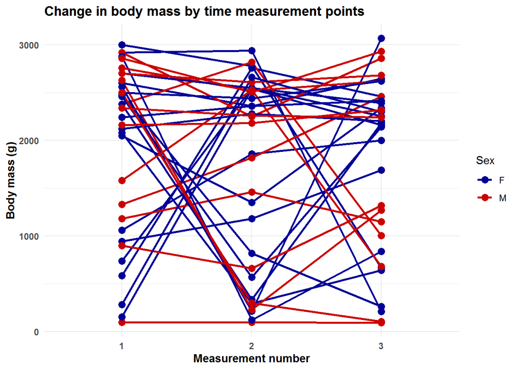

```r
custom_colors <- c("#000099", "#CC0000")
#Построим график
ggplot(tac, aes(x = measurement, y = weight, group = name, color = sex)) +
  geom_line(linetype = "solid", size = 1) + #Стиль линий
  geom_point(shape = 16, size = 3) + #Стиль точек
  labs(title="Change in body mass by time measurement points", x = "Measurement number", y = "Body mass (g)", color = "Sex") + #Установим обозначения
  theme_minimal() + #Установим стили
  theme(axis.text = element_text(face = "bold"),
        axis.title = element_text(face = "bold"),
        plot.title = element_text(face = "bold"))+
  scale_color_manual(values = custom_colors) #Установим цвета для значений
```

# Задание №4

## Задание №4.1

> В этом и последующих заданиях вы будете использовать датасет, полученный в результате секвенирования РНК единичных клеток. Вам понадобятся объединенная таблица с экспрессиями (каунтами) разных генов и таблица с метаданными. Эти данные можно скачать в виде zip по ссылке https://raw.githubusercontent.com/kirushka/datasets/main/scrna.zip. Разархивируйте файл в свою рабочую директорию (для этого использовать R не нужно, делайте это как вам привычнее).

> Датасет состоит из нескольких частей:

> в папке counts - таблицы с экспрессией генов (таблица с каунтами) - всего 13714 гена x 600 клеток. В каждом файле данные по 100 клеткам. Столбец gene содержит символьные обозначения генов, названия остальных столбцов - это идентификаторы индивидуальных клеток. cells_metadata.tsv - метаданные - аннотация клеток по типам. Создайте список файлов с таблицами с каунтами и, используя map, прочитайте все файлы в один датафрейм (соединяя индивидуальные датафреймы по столбцам - из 6 датафреймов размера 13714 х 101 у вас должен получиться одни датафрейм размера 13714 х 606). Старайтесь не самостоятельно задавать названия нужных файлов, а например, пользоваться функциями, которые выдают названия всех или не всех файлов в директории.

> Выведите названия всех столбцов, содержащих тип данных character.

> Если использованный вами подход привел к тому, что у вас появилось несколько дублирующихся столбцов с названиями генов, то отберите для дальнейшей работы только один столбец с именами генов и все столбцы с каунтами.

> Сохраните полученный датафрейм в текстовый файл.

```r
#Я скачал архив, распаковал его. И положил в рабочую директорию два объекта. Одну папку counts и файл cells_metadata.tsv

input_files <- dir("./counts/") #Занесем в вектор input_files имена всех .tsv в папке counts, которая находится в текущей директории

input_files <- paste("./counts/", input_files, sep="") #Добавим путь к файлам из текущей директории
head(input_files, n = 5)
```

```
## [1] "./counts/pmbc_01.tsv" "./counts/pmbc_02.tsv" "./counts/pmbc_03.tsv"
## [4] "./counts/pmbc_04.tsv" "./counts/pmbc_05.tsv"
```

```r
#Напишем функцию для чтения файла и добавления имени файла в dataframe
read_file <- function(file) {
  df <- read_tsv(file, show_col_types = FALSE) #Прочитаем файлы, уберем предупреждения
  return(df)
}

#Объединяем результаты в один dataframe
result <- map_dfc(input_files, read_file)
dim(result)
```

```
## [1] 13714   606
```

```r
#Выведем названия всех столбцов, содержащих тип character
names(result)[map_lgl(result, is.character)]
```

```
## [1] "gene...1"   "gene...102" "gene...203" "gene...304" "gene...405"
## [6] "gene...506"
```

```r
#Отберем один столбец с названиями генов и выведем размеры
genes <- result %>%
  select(-(contains("0")))
dim(genes)
```

```
## [1] 13714   601
```

```r
#Выведем названия всех столбцов, содержащих тип character после удаления дубликатов-столбцов
names(genes)[map_lgl(genes, is.character)]
```

```
## [1] "gene...1"
```

```r
#Запишем файл в текстовом формате с расширением .csv
write_csv(genes, "genes.csv", append = FALSE)
```

## Задание №4.2

> Прочитайте полученный в предыдущем задании датафрейм и метаданные к нему (лежат рядом с папкой counts/).

> Используя датафрейм с метаданными о клетках, случайным образом отберите по 25 клеток каждого типа (B cells, T cells и Monocytes).

> Используя подвыборку, состоящую из отобранных клеток, удалите из данных экспрессии гены, которые имеют значение 0 во всех клетках. Посчитайте среднюю экспрессию и стандартное отклонение экспрессии для каждого гена (это может занять некоторое время). Оставьте только те гены, у которых средняя экспрессия выше 0.1. Возьмите 100 генов с самой вариабельной экспрессией (высоким стандартным отклонением) и случайным образом выберите 25 генов. Сохраните полученный датафрейм в текстовый файл.

> Не бойтесь разбивать это задание на несколько шагов и записывать промежуточные результаты в отдельные переменные.

> В итоге у вас должен получиться датасет из 75 клеток и 25 генов.

```r
#Прочитаем предыдущий файл, который мы получили
gen <- read_csv("genes.csv", show_col_types = FALSE)
metadata <- read_tsv("cells_metadata.tsv", show_col_types = FALSE)

#Отберем 25 B cells случайно
set.seed(123)
b_cells <- metadata %>% filter(cell_type == "B cells") %>% sample_n(25)

#Отберем 25 T cells случайно
set.seed(123)
t_cells <- metadata %>% filter(cell_type == "T cells") %>% sample_n(25)

#Отберем 25 Monocytes случайно
set.seed(123)
monocytes <- metadata %>% filter(cell_type == "Monocytes") %>% sample_n(25)

#Занесем в вектор cells названия всех столбцов, которые нам надо взять
cells <- c("gene",pull(monocytes, cell_id), pull(b_cells, cell_id), pull(t_cells, cell_id))
head(cells, n = 5)
```

```
## [1] "gene"             "TACGCCACTCCCAC-1" "TGATCGGATATGCG-1" "ACAGCAACACCTAG-1"
## [5] "TTCGAGGATAGAAG-1"
```

```r
#Отберем из genes наши клетки
pre_data <- gen %>%
  select(all_of(cells))
dim(pre_data)
```

```
## [1] 13714    76
```

```r
# Удаление генов, которые имеют значение 0 во всех клетках
# Выборка строк с суммой, кроме столбца "gene"
data <- pre_data %>%
  filter(rowSums(.[, !colnames(.) %in% "gene"]) != 0)
dim(data)
```

```
## [1] 8981   76
```

```r
#Добавим столбец со средней экспрессией для каждого гена
data <- data %>%
  mutate(average_expression = rowMeans(across(-1)))

#Добавим столбец со CO экспрессией для каждого гена
data <- data %>%
  mutate(standard_deviation = apply(.[-c(1, ncol(.))], 1, sd))
dim(data)
```

```
## [1] 8981   78
```

```r
#Отберем гены с СО > 0.1
filtered_genes <- data %>%
  filter(average_expression > 0.1)
dim(filtered_genes)
```

```
## [1] 2276   78
```

```r
#Отсортируем гены в порядке убывания CO
sorted_genes <- arrange(data, desc(standard_deviation))
head(sorted_genes, n = 5)
```

```
## # A tibble: 5 x 78
##   gene   `TACGCCACTCCCAC-1` `TGATCGGATATGCG-1` `ACAGCAACACCTAG-1`
##   <chr>               <dbl>              <dbl>              <dbl>
## 1 FTL                   222                 72                 37
## 2 FTH1                  198                 72                 47
## 3 TMSB4X                154                 55                 41
## 4 MALAT1                 72                 21                  9
## 5 B2M                   126                 26                 12
## # i 74 more variables: `TTCGAGGATAGAAG-1` <dbl>, `TCAGGATGCCTTTA-1` <dbl>,
## #   `ATCGTTTGGGTACT-1` <dbl>, `GACTGAACCAATCG-1` <dbl>,
## #   `ATACGTCTTAACGC-1` <dbl>, `TTGAGGACAGAACA-1` <dbl>,
## #   `TTCCTAGACTAGTG-1` <dbl>, `GTTGGATGTTTACC-1` <dbl>,
## #   `CGGATAACAACGAA-1` <dbl>, `CGGATAACTCAGTG-1` <dbl>,
## #   `TGTTACACCGCATA-1` <dbl>, `TGTGAGACTGTCAG-1` <dbl>,
## #   `CGGCACGACTACGA-1` <dbl>, `GGATTTCTTTGTCT-1` <dbl>, ...
```

```r
#Выберем 100 генов по CO
top_100_genes <- sorted_genes %>%
  slice(1:100)
head(top_100_genes)
```

```
## # A tibble: 6 x 78
##   gene   `TACGCCACTCCCAC-1` `TGATCGGATATGCG-1` `ACAGCAACACCTAG-1`
##   <chr>               <dbl>              <dbl>              <dbl>
## 1 FTL                   222                 72                 37
## 2 FTH1                  198                 72                 47
## 3 TMSB4X                154                 55                 41
## 4 MALAT1                 72                 21                  9
## 5 B2M                   126                 26                 12
## 6 RPL10                  21                 12                 10
## # i 74 more variables: `TTCGAGGATAGAAG-1` <dbl>, `TCAGGATGCCTTTA-1` <dbl>,
## #   `ATCGTTTGGGTACT-1` <dbl>, `GACTGAACCAATCG-1` <dbl>,
## #   `ATACGTCTTAACGC-1` <dbl>, `TTGAGGACAGAACA-1` <dbl>,
## #   `TTCCTAGACTAGTG-1` <dbl>, `GTTGGATGTTTACC-1` <dbl>,
## #   `CGGATAACAACGAA-1` <dbl>, `CGGATAACTCAGTG-1` <dbl>,
## #   `TGTTACACCGCATA-1` <dbl>, `TGTGAGACTGTCAG-1` <dbl>,
## #   `CGGCACGACTACGA-1` <dbl>, `GGATTTCTTTGTCT-1` <dbl>, ...
```

```r
#Выберем случайным образом 25 генов из топ 100
set.seed(123)
random_genes <- top_100_genes %>%
  slice_sample(n=25)

head(random_genes, n = 5)
```

```
## # A tibble: 5 x 78
##   gene   `TACGCCACTCCCAC-1` `TGATCGGATATGCG-1` `ACAGCAACACCTAG-1`
##   <chr>               <dbl>              <dbl>              <dbl>
## 1 RPS12                  14                  2                  5
## 2 FAU                    15                  4                  1
## 3 RPL12                  15                  5                  3
## 4 CD74                    7                  0                  2
## 5 UBE2L6                  0                  1                  0
## # i 74 more variables: `TTCGAGGATAGAAG-1` <dbl>, `TCAGGATGCCTTTA-1` <dbl>,
## #   `ATCGTTTGGGTACT-1` <dbl>, `GACTGAACCAATCG-1` <dbl>,
## #   `ATACGTCTTAACGC-1` <dbl>, `TTGAGGACAGAACA-1` <dbl>,
## #   `TTCCTAGACTAGTG-1` <dbl>, `GTTGGATGTTTACC-1` <dbl>,
## #   `CGGATAACAACGAA-1` <dbl>, `CGGATAACTCAGTG-1` <dbl>,
## #   `TGTTACACCGCATA-1` <dbl>, `TGTGAGACTGTCAG-1` <dbl>,
## #   `CGGCACGACTACGA-1` <dbl>, `GGATTTCTTTGTCT-1` <dbl>, ...
```

```r
dim(random_genes)
```

```
## [1] 25 78
```

```r
#Сохраним датафрейм в текстовый файл с расширение .csv
write.csv(random_genes, file = "random_genes.csv")
```

## Задание №4.3

> Прочитайте датасет из 75 клеток и 25 генов, полученный в предыдущем задании. Также вам понадобятся метаданные.

> Выберите 2 любых гена из вашего датасета и постройте точковую диаграмму, показывающую экспрессию этих генов в отобранных клетках. Цветом отобразите уровень экспрессии любого гена (используйте градиент) и формой точек укажите тип клеток (cell_type).

> Для создания такого графика вам необходимо будет привести данные в нужный формат (используйте функции pivot_longer/pivot_wider) и объединить датафрейм со значениями экспрессии генов и метаданными.

> Сохраните график.

```r
#Прочитаем предыдущий файл, который мы получили
gene_data <- read_csv("random_genes.csv", show_col_types = FALSE)
```

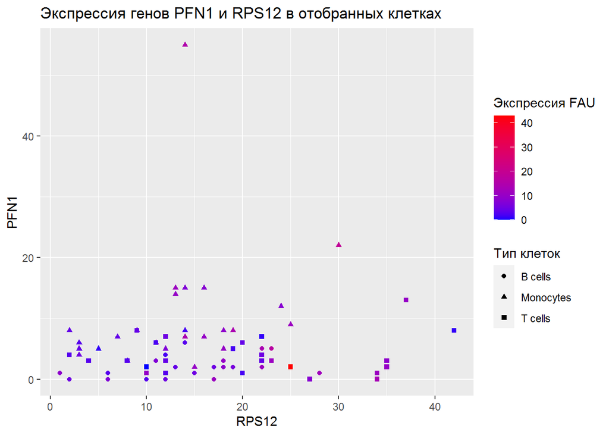

```r
metadata <- read_tsv("cells_metadata.tsv", show_col_types = FALSE)

#Переведем таблицу экспрессии в длинный формат
gene_data_long <- pivot_longer(gene_data, cols = -gene, names_to = "cell_id", values_to = "expression")

#Оьъединим данные с метаданными
merged_data <- left_join(gene_data_long, metadata, by = "cell_id")

#Выберем гены
selected_genes <- merged_data %>% filter(gene %in% c("RPS12", "PFN1", "FAU"))

#Уберем лишние строки, которые появились, когда переводили в длинный формат
selected_genes <- selected_genes %>%
  filter(!grepl("_|\\.\\.\\.1", cell_id)) %>%
  select(gene, cell_id, expression, cell_type)

#Приведем таблицу к широкому формату
maybe <- pivot_wider(selected_genes, names_from = gene, values_from = expression)

#Построим график
plot <- ggplot(maybe, aes(x = RPS12, y = PFN1, color = FAU, shape = cell_type)) +
  geom_point() +
  scale_color_gradient(low = "blue", high = "red") + #Установим цветовой градиент
  labs(x = "RPS12", y = "PFN1", title = "Экспрессия генов PFN1 и RPS12 в отобранных клетках", color = "Экспрессия FAU", shape = "Тип клеток") #Установим обозначения
plot
```

```r
ggsave("scatter_plot.jpg", plot = plot) #Сохраним файл в формате .jpg
```